# Fit Wind Speed Profile

Hao-Ran Wu ( haoranwu @ zju.edu.cn )

2022-09-15

In this section we are concerned about how to fit wind speed profile through the function `ws()`.

## Code Example(s)

```r
# Fit Wind Speed Profile
# ********************************
#
# Fit wind speed profile from measured wind speeds at various heights.
#
# ********************************
# List of variables and units for this example
#
# 'path'        path of a CSV file, which contains two columns (with table titles)
#                * column 1: height above ground level (m)
#                * column 2: horizontal wind speed (m s−1) at height z (m)
#
# ********************************
# Step 1: import package
require(bproce)

# Step 2: choose parameters
path  <- "./data/1-7C Simulated Wind Speed Profile.csv"

# Step 3: read data
dat   <- read.csv(path)              # read the CSV file
                                     #  * column 1 ($z): height above ground level
                                     #  * column 2 ($uz): wind speed

# Step 4: fit the model
md <- with(dat, ws(z, uz, mode = "windu"))

fitted_ustar <- md$coef[["ustar"]]   # extract fitted model paramters
fitted_kappa <- md$coef[["kappa"]]
fitted_d     <- md$coef[["d"]]
fitted_z0    <- md$coef[["z0"]]

cat(
  paste("***** Fit wind speed profile *****\n"),
  paste("ustar = ", fitted_ustar, "(m s−1)\n"),
  paste("kappa = ", fitted_kappa, "\n"),
  paste("d = ", fitted_d, "(m)\n"),
  paste("z0 = ", fitted_z0, "(m)\n"),
  paste("Multiple R-squared:", md$r.square,"\n"),
  paste("Adjusted R-squared:", md$adj.r.square,"\n")
)

# Step 5: model prediction
predicted_uz <- ws(dat$z, z0 = fitted_z0, d = fitted_d,
                   ustar = fitted_ustar, mode = "windz")
                             # calculate wind speed based on the fitted model

plot(
  dat$uz, dat$z,
  xlab = "Horizontal wind speed",
  ylab = "Height above ground level",
  main = "Vertical Profile of Wind Speed"
)                            # plot heights versus observed wind speed
lines(predicted_uz, dat$z)   # plot fitted curve of wind speed
```

## Explanation

**Step1:** Load the package `bproce` through the `require()` function.

```r
require(bproce)
```

**Step2:** Choose model parameters.

- `path`: the path of a CSV file which the data are to be read from. Each row of the file appears as one line, and columns are separated by commas (,). The first row appears as the table title. There should be twocolumns in this file:
  - Column 1: height above ground level (m).
  - Column 2: horizontal wind speed (m s<sup>−1</sup>) at height z (m).

```r
path  <- "./data/1-7C Simulated Wind Speed Profile.csv"
```

**Step3:** Read data. Read the CSV file in table format and creates a data frame through the function `read.csv()`.

```r
dat <- read.csv(path)
print(head(dat), digits = 3)    #print first parts of the data
```

```
    z   uz
1 1.0 1.05
2 1.1 1.12
3 1.2 1.14
4 1.3 1.14
5 1.4 1.18
6 1.5 1.18
```

**Step4:** Fit the model. As discussed in Section 1-7A, the wind profile of homogeneous vegetation under neutral atmospheric conditions is typically expressed as:

$$U(z)=\frac{u^*}{\kappa}·\ln(\frac{z-d}{z_0}),\quad(1)$$

where $U(z)$ is the horizontal wind speed (m s<sup>−1</sup>) at height $z$ (m); $u^∗$ is the friction velocity (m s<sup>−1</sup>), $\kappa$ is the von Karmon constant with an average value of 0.35 – 0.43 (a value of 0.40 is often used in the literature), $d$ (m) is a zero plain displacement, and $z_0$ is the roughness length (m) at which is $U$ is near zero.

```r
md <- with(dat, ws(z, uz, mode = "windu"))
```

The arguments and their meaning of the function `ws()` that might change the calculated result in this example are shown in the table below:

| Argument | Data Type | Meaning | Symbol |
| --- | --- | --- | --- |
| `z` | vector | height above ground level (m) | $z$ |
| `uz` | vector | horizontal wind speed (m s<sup>−1</sup>) at height z (m) | $U(z)$ |
| `kappa` | scalar | von Karmon constant. Default 0.4 | $\kappa$ |
| `windu.dmax` | scalar | maximal zero plain displacement `d` to be considered when fitting the wind profile | / |
| `mode` | character | options of analysis. Must be set as `"windu"` to fit wind speed profile | / |

Now we can take a look at the fitted values of model parameters.

```r
fitted_ustar <- md$coef[["ustar"]]   # extract fitted model paramters
fitted_d     <- md$coef[["d"]]
fitted_z0    <- md$coef[["z0"]]

cat(
  paste("***** Fit wind speed profile *****\n"),
  paste("ustar = ", round(fitted_ustar, 3), "(m s−1)\n"),
  paste("d = ", round(fitted_d, 3), "(m)\n"),
  paste("z0 = ", round(fitted_z0, 3), "(m)\n"),
  paste("Multiple R-squared:", round(md$r.square, 3),"\n"),
  paste("Adjusted R-squared:", round(md$adj.r.square, 3),"\n")
)
```

```
***** Fit wind speed profile *****
 ustar =  0.099 (m s−1)
 d =  0.108 (m)
 z0 =  0.011 (m)
 Multiple R-squared: 0.969
 Adjusted R-squared: 0.969
```

**Step 5:** Model prediction. Predict the wind speed at different heights based on the fitted model:

```r
predicted_uz <- ws(dat$z, z0 = fitted_z0, d = fitted_d,
                   ustar = fitted_ustar, mode = "windz")
```

Create a plot of height against wind speed to compare observed and predicted values:

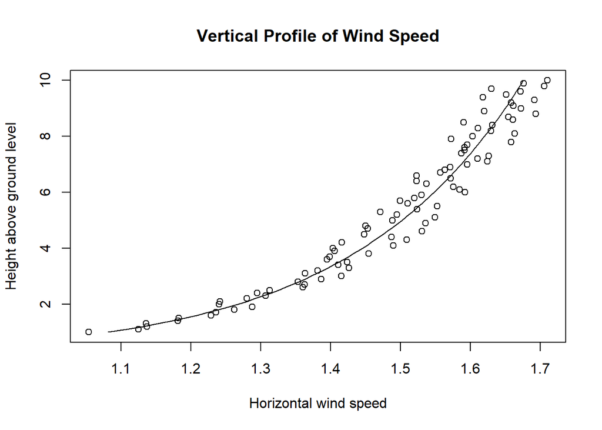

```r
plot(
  dat$uz, dat$z,
  xlab = "Horizontal wind speed",
  ylab = "Height above ground level",
  main = "Vertical Profile of Wind Speed"
)                            # plot heights versus observed wind speed
lines(predicted_uz, dat$z)   # plot fitted curve of wind speed
```

The dots appear on the plot represent the observed values, whilst the solid curve represents the fitted curve of wind speed. It can be seen that the model gives an accurate and reliable prediction of wind speeds at different heights.